# Workshop 3_Timeseries Models

Sparkle L. Malone

1/24/2020

# Objectives

The primary objectives of this analysis is …

1 Plot, examine, and prepare time series for modeling

2 Extract the seasonality component from the time series

3 Test for stationarity and apply appropriate transformations

4 Choose the order of an ARIMA model

# Methods

## Site Information

The data provided in ARIMA_Workshop includes one data set of daily rates of NEE for a tower site in a mangrove scrub (mangroves) along the coast of Florida. The dataset includes gap-filled NEE (g C m2 day−1). Data was obtained from an eddy covariance tower in Everglades National Park at the Florida Coastal Everglades Long-term Ecological Research site TS/Ph-7. Data includes NEE (g C m2 day−1), total daily PAR (par; W m−2 day−1), air temperature (tair; C), water temperature minimum and maximum, (water.tmax and water.min; C), and water salinity minimum, maximum, and mean (salinity.min, salinity.max, salinity.mean; ppt).

In this report, there is a focus on NEE (g C m2 day−1), and water temperature maximum, (water.tmax; C).

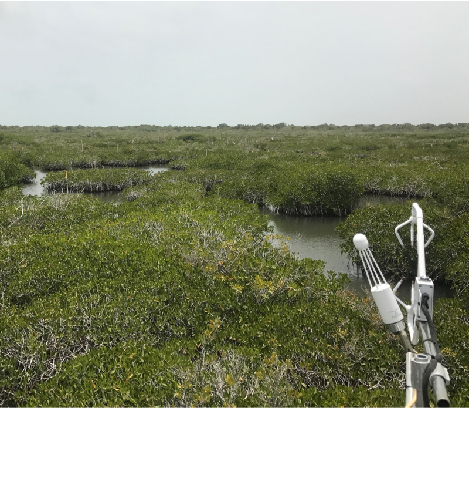

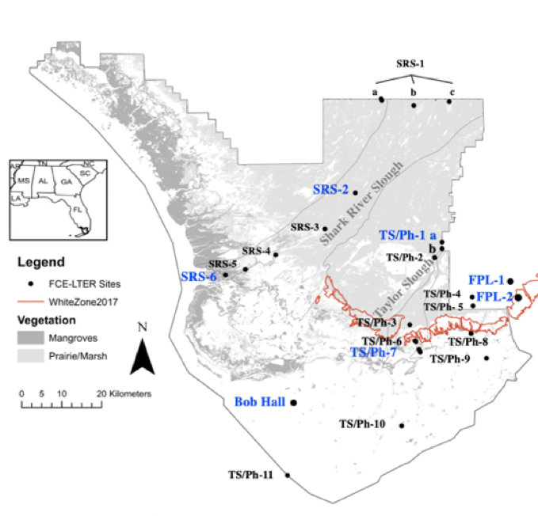

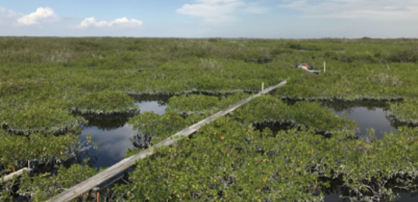

## Statistical Analysis

load(“/Users/helen/Documents/EcologyRWorkshop/Time_Series_Analysis/Github/ARIMA_Workshop.RData”)

library(zoo) library(tseries) library(forecast) library(xts) library(fracdiff)

### Starting with NEE Practice data:

#### Part 1:

##### 1. Create timeseries objects:

nee <- ts( mangroves$nee, start= 1, frequency=30)

##### Visualize data:

The timeseries is visually examined for any outliers, volatility, or irregularities. (LEFT). Any outliers that could bias the model by skewing statistical summaries are removed using series smoothing and decomposition. (RIGHT).

par(mfrow=c(1,1), mai=c(1.25,0.8,0.1, 0.1)) plot( nee, typ=“l”, ylab= “NEE”, xlab="")

plot(nee) lines(tsclean(nee), col=“red”)

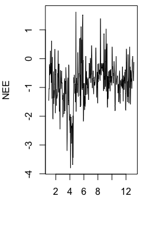

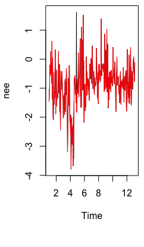

nee <- tsclean(nee)

#### 2. Decompose the timeseries:

Deconstructing helps prepare a foundation for building an ARIMA model:

nee.d <- decompose(nee, ‘multiplicative’) plot(nee.d)

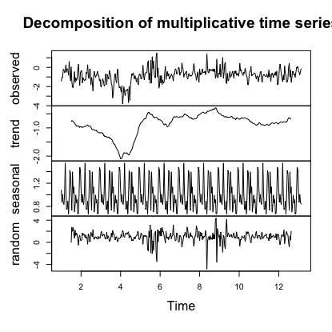

#### 3.a. Test for stationarity

Fitting an ARIMA model requires the series to be stationary. The augmented Dickey-Fuller (ADF) test was run as a formal statistical test for stationarity. The null hypothesis assumes that the series is non-stationary.

##### p-value < 0.05 indicates the TS is stationary

adf.test(nee)

Augmented Dickey-Fuller Test

data: nee Dickey-Fuller = -4.4703, Lag order = 7, p-value = 0.01 alternative hypothesis: stationary

#### 3.b. Detecting Autocorrelation:

The following autocorrelation plots (also known as ACF or the auto correlation function) display correlation between a series and its lags.

On the left, ACF plots help in determining the order of the MA (q) model. The partial autocorrelation plots (PACF) on the right display correlation between a variable and its lags that is not explained by previous lags.

acf(nee, lag.max=45) # (LEFT)

pacf(nee, lag.max=45) # (RIGHT)

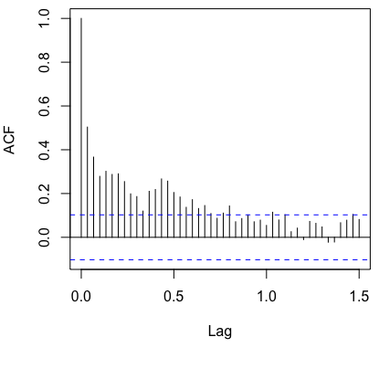

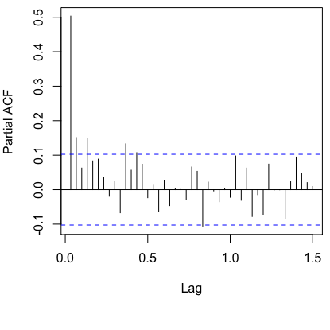

#### 4. Fitting an ARIMA Model:

This function searches through combinations of order parameters and picks the set that optimizes model fit criteria.

arima.nee1 <-auto.arima(nee, trace=TRUE)

```r
# ARIMA(2,1,3)(2,0,2)[30]                    : 706.7137

# Best: ARIMA(2,1,3)(2,0,2)[30]
```

tsdisplay(residuals(arima.nee1), lag.max=45)

arima.nee2 <-arima(nee , order=c(10,1,3), seasonal= list(order=c(2,0,2)))

```r
# Warning message:
# In arima(nee, order = c(10, 1, 3), seasonal = list(order = c(2,  :
  #possible convergence problem: optim gave code = 1
```

tsdisplay(residuals(arima.nee2), lag.max= 30)

NEE Residual graphs for NEE1 (Left) and NEE2 (Right)

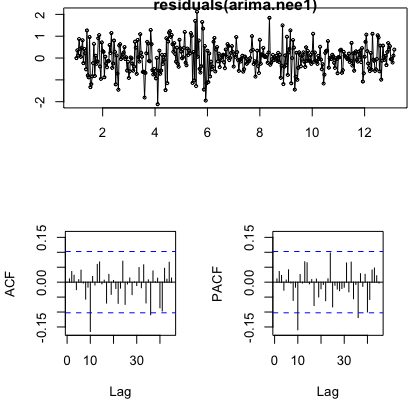

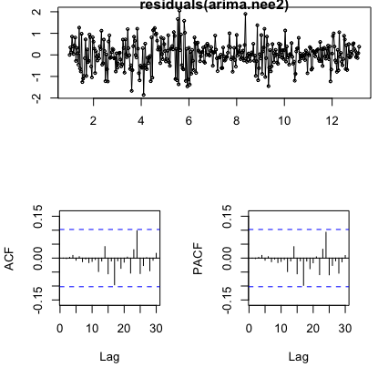

##### You want to minimize AIC

AIC(arima.nee1, arima.nee2)

kable(AIC(arima.nee1,arima.nee2 ), format = “html”, digits = 1) %>% kable_styling(bootstrap_options = “striped”, full_width = F)

|  | df | AIC |
| --- | --- | --- |
| arima.nee1 | 10 | 706.1 |
| arima.nee2 | 18 | 704.8 |

par(mfrow=c(1,1)) plot(nee , typ=“l”); lines(fitted(arima.nee2),col=“red”)

##### Measuring for significant difference from white noise.

par(mfrow=c(1,1)) plot(nee , typ=“l”); lines(fitted(arima.nee2),col=“red”)

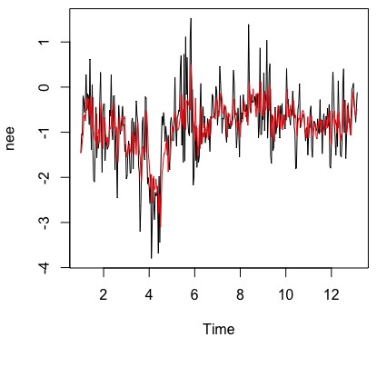

### Using water.tmax to develop a better model:

#### Part 1:

##### 1. Create timeseries objects:

wat <- ts( mangroves$water.tmax, start= 1, frequency=30)

##### Visualize data:

The timeseries is visually examined for any outliers, volatility, or irregularities. (LEFT). Any outliers that could bias the model by skewing statistical summaries are removed using series smoothing and decomposition. (RIGHT).

par(mfrow=c(1,1), mai=c(1.25,0.8,0.1, 0.1)) plot( wat, typ=“l”, ylab= “WaterTemp”, xlab="")

plot(wat, typ=“l”, ylab= “WaterTemp”, xlab="“) lines(tsclean(wat), col=”red")

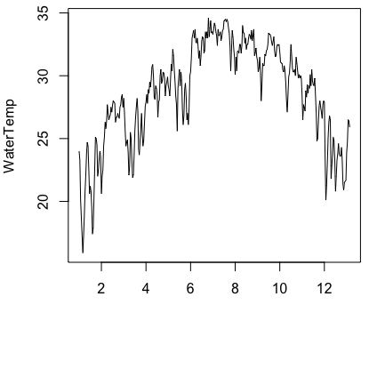

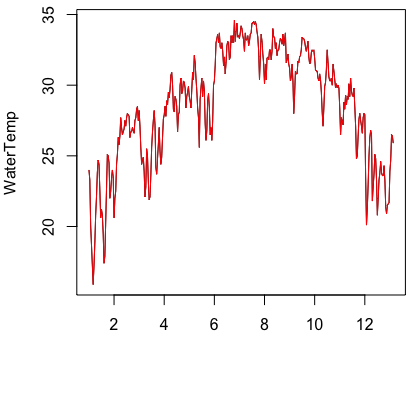

wat <- tsclean(wat)

#### 2. Decompose the timeseries:

Deconstructing helps prepare a foundation for building an ARIMA model:

wat.d <- decompose(wat, ‘multiplicative’) plot(wat.d)

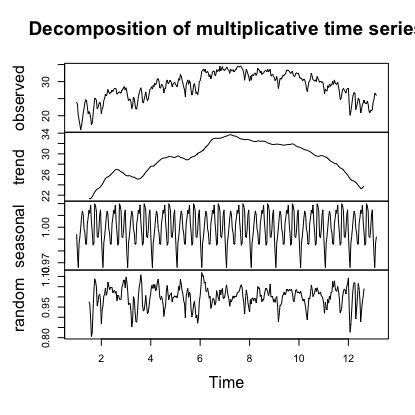

#### 3. Test for stationarity

Fitting an ARIMA model requires the series to be stationary. The augmented Dickey-Fuller (ADF) test is a formal statistical test for stationarity. The null hypothesis null hypothesis was not rejected, so the time series was differentiated. After differentiation, the null hypothesis was rejected.

###### p-value < 0.05 indicates the TS is stationary

adf.test(wat)

```r
#Augmented Dickey-Fuller Test

#data:  wat
#Dickey-Fuller = -2.1936, Lag order = 7, p-value = 0.4952
#alternative hypothesis: stationary
```

adf.test(diff(wat))

```r
#Augmented Dickey-Fuller Test

#data:  diff(wat)
#Dickey-Fuller = -9.4432, Lag order = 7, p-value = 0.01
#alternative hypothesis: stationary
```

#### 4. Explore correlations.

Look for significant lags.

ccf( diff(wat),nee, na.action = na.pass, lag.max=40, plot=TRUE)

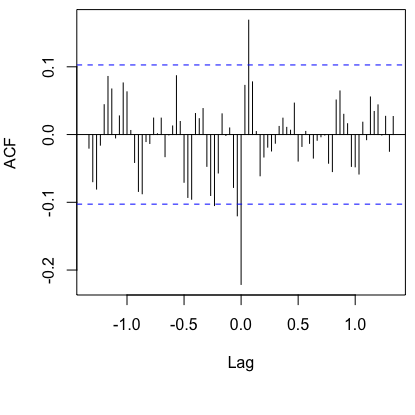

#### 5. Explore Models of NEE.

arima.nee3 <-auto.arima(nee, xreg=c(diff(wat),0), trace=TRUE)

```r
#ARIMA(3,1,1)(2,0,1)[30]                    : 698.1553

# Best model: Regression with ARIMA(3,1,1)(2,0,1)[30] errors
```

##### Compare to current model

AIC(arima.nee2, arima.nee3 )

kable(AIC(arima.nee2,arima.nee3 ), format = “html”, digits = 1) %>% kable_styling(bootstrap_options = “striped”, full_width = F)

|  | df | AIC |
| --- | --- | --- |
| arima.nee2 | 18 | 704.8 |
| arima.nee3 | 9 | 697.6 |

So, adding water temperature to nee did improve the model. Maybe extreme water temperature is more important. Lets create a water temperature index to ID when water temperature values are greater than 25n ppt.

wat.i <- wat wat.i[wat.i < 25 ]<- 0 wat.i[wat.i >= 25 ]<- 1 plot(wat.i)

[figure not shown]

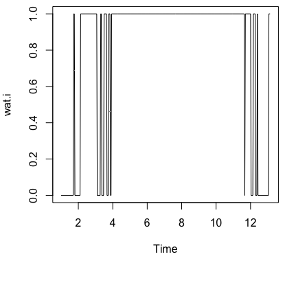

arima.nee4 <-auto.arima(nee, xreg=wat.i, trace=TRUE)

```r
#ARIMA(0,1,3)(2,0,1)[30]                    : 692.1087

# Best model: Regression with ARIMA(0,1,3)(2,0,1)[30] errors
```

AIC(arima.nee2,arima.nee4 )

kable(AIC(arima.nee2,arima.nee4 ), format = “html”, digits = 1) %>% kable_styling(bootstrap_options = “striped”, full_width = F)

|  | df | AIC |
| --- | --- | --- |
| arima.nee2 | 18 | 704.8 |
| arima.nee4 | 8 | 691.7 |

checkresiduals(arima.nee4, lag=36)

par(mfrow=c(1,1)) plot(nee , typ=“l”); lines(fitted(arima.nee4),col=“red”)

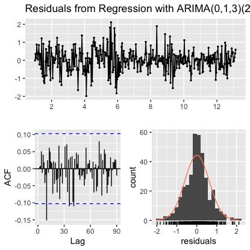

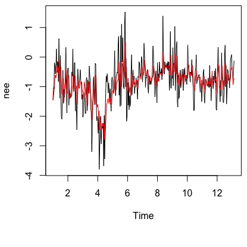